| title: “Business Analytics Project” author: “Devjyoti Kundu” date: “2026-08-06” output: html_document |
| --- |
| Topic: FMCG Urban versus Rural market Penetration |

# Project Theme

FMCG Rural versus Urban Market Penetration

FMCG (Fast-Moving Consumer Goods) are products that are purchased frequently and generally consumed quickly, such as packaged food, beverages, personal-care products, household-care products and other daily-use products.

The project aims to investigate how FMCG market penetration differs between rural and urban markets in India.

# Type of Analytics Selected: Descriptive Analytics:

For the first stage of the project, I have selected Descriptive Analytics.

Descriptive analytics focuses on understanding and summarizing existing data. In this project, it can help us understand the differences in FMCG consumption/penetration between rural and urban consumers. # The single most question which we are investigating: How do FMCG purchasing patterns, consumer behavior, and transaction spending differ between rural and urban markets in India, and what business insights can be derived from these differences?

#The analysis includes: i)FMCG consumption by rural and urban households ii)Penetration of different FMCG categories iii)Regional differences iv)Consumer spending patterns v)Differences in household characteristics vi)Changes in consumption over time, if time-series data are available

#Source of Data: India - Household Consumption Expenditure Survey: 2022-23 https://share.google/ZP1dZLD6tiizWGeAI

merging of LEVEL-01(Section 1 and 1_1) & LEVEL05

# Indian FMCG Market Analysis

## Rural vs Urban Business Analytics

```r
packages <- c(
  "readr", "dplyr", "tidyr", "ggplot2",
  "janitor", "stringr", "lubridate",
  "corrplot", "broom", "car", "lmtest",
  "knitr", "scales"
)

new_packages <- setdiff(
  packages,
  rownames(installed.packages())
)

if(length(new_packages) > 0) {
  install.packages(new_packages)
}

invisible(lapply(packages, library, character.only = TRUE))

theme_set(theme_minimal(base_size = 12))
set.seed(123)
```

# 1. Data Import

```r
file_path <- file.choose()

data_raw <- readr::read_csv(
  file_path,
  show_col_types = FALSE,
  guess_max = 20000
)

data <- data_raw %>%
  janitor::clean_names()

cat("Rows:", nrow(data), "\n")
```

```
## Rows: 200000
```

```r
cat("Columns:", ncol(data), "\n")
```

```
## Columns: 31
```

```r
names(data)
```

```
##  [1] "transaction_id"
##  [2] "customer_id"
##  [3] "transaction_date"
##  [4] "state_ut"
##  [5] "district_cluster_synthetic"
##  [6] "country"
##  [7] "area_type"
##  [8] "age"
##  [9] "gender"
## [10] "household_size"
## [11] "estimated_monthly_household_income_inr"
## [12] "reference_mpce_2023_24_inr"
## [13] "product_category"
## [14] "product_name"
## [15] "brand"
```

[output cut: 16 more lines]

```r
head(data)
```

```
## # A tibble: 6 × 31
##   transaction_id customer_id transaction_date state_ut    district_cluster_syn…¹
##   <chr>          <chr>       <chr>            <chr>       <chr>
## 1 TXN0000001     CUST051328  13-11-2024       Assam       ASS_CL01
## 2 TXN0000002     CUST049659  31-05-2024       Gujarat     GUJ_CL06
## 3 TXN0000003     CUST023507  19-05-2024       Bihar       BIH_CL06
## 4 TXN0000004     CUST014557  23-08-2024       Madhya Pra… MAD_CL03
## 5 TXN0000005     CUST003750  16-03-2025       Telangana   TEL_CL04
## 6 TXN0000006     CUST042875  24-10-2024       Maharashtra MAH_CL05
## # ℹ abbreviated name: ¹district_cluster_synthetic
## # ℹ 26 more variables: country <chr>, area_type <chr>, age <dbl>, gender <chr>,
## #   household_size <dbl>, estimated_monthly_household_income_inr <dbl>,
## #   reference_mpce_2023_24_inr <dbl>, product_category <chr>,
## #   product_name <chr>, brand <chr>, brand_preference <chr>,
## #   purchase_frequency <chr>, purchase_channel <chr>, store_type <chr>,
## #   payment_method <chr>, quantity <dbl>, unit_price_inr <dbl>, …
```

# 2. Data Understanding

```r
dim(data)
```

```
## [1] 200000     31
```

```r
str(data)
```

```
## spc_tbl_ [200,000 × 31] (S3: spec_tbl_df/tbl_df/tbl/data.frame)
##  $ transaction_id                        : chr [1:200000] "TXN0000001" "TXN0000002" "TXN0000003" "TXN0000004" ...
##  $ customer_id                           : chr [1:200000] "CUST051328" "CUST049659" "CUST023507" "CUST014557" ...
##  $ transaction_date                      : chr [1:200000] "13-11-2024" "31-05-2024" "19-05-2024" "23-08-2024" ...
##  $ state_ut                              : chr [1:200000] "Assam" "Gujarat" "Bihar" "Madhya Pradesh" ...
##  $ district_cluster_synthetic            : chr [1:200000] "ASS_CL01" "GUJ_CL06" "BIH_CL06" "MAD_CL03" ...
##  $ country                               : chr [1:200000] "India" "India" "India" "India" ...
##  $ area_type                             : chr [1:200000] "Rural" "Urban" "Urban" "Rural" ...
##  $ age                                   : num [1:200000] 64 50 18 20 37 62 67 26 36 34 ...
##  $ gender                                : chr [1:200000] "Female" "Male" "Female" "Male" ...
##  $ household_size                        : num [1:200000] 2 1 1 3 5 3 2 3 6 4 ...
##  $ estimated_monthly_household_income_inr: num [1:200000] 37710 13220 16780 16090 124860 ...
##  $ reference_mpce_2023_24_inr            : num [1:200000] 3793 7175 5080 3441 5435 ...
##  $ product_category                      : chr [1:200000] "Dairy & Bakery" "Health & Hygiene" "Packaged Foods" "Packaged Foods" ...
##  $ product_name                          : chr [1:200000] "Bread" "Toothbrush" "Chips & Namkeen" "Breakfast Cereal" ...
##  $ brand                                 : chr [1:200000] "ITC" "Godrej Consumer" "HUL" "Parle" ...
##  $ brand_preference                      : chr [1:200000] "Preferred brand" "Preferred brand" "Preferred brand" "Preferred brand" ...
##  $ purchase_frequency                    : chr [1:200000] "Monthly" "2-3 times/month" "Monthly" "Monthly" ...
##  $ purchase_channel                      : chr [1:200000] "Wholesale/Other" "Kirana/General Store" "Wholesale/Other" "Kirana/General Store" ...
##  $ store_type                            : chr [1:200000] "Wholesale/Other" "Kirana" "Wholesale/Other" "Kirana" ...
##  $ payment_method                        : chr [1:200000] "Debit/Credit Card" "Debit/Credit Card" "Cash" "Cash" ...
##  $ quantity                              : num [1:200000] 3 4 5 2 3 3 3 1 3 1 ...
##  $ unit_price_inr                        : num [1:200000] 30.8 31.8 19.6 221.6 236.6 ...
##  $ discount_percent                      : num [1:200000] 11.2 34.3 9.8 6.8 18.3 19.7 3.8 19.5 7.7 4 ...
##  $ gross_amount_inr                      : num [1:200000] 92.4 127.3 98.2 443.2 709.9 ...
##  $ tax_amount_inr                        : num [1:200000] 4.1 15.06 4.43 20.65 29 ...
##  $ net_transaction_amount_inr            : num [1:200000] 86.1 98.7 93 433.7 609 ...
##  $ promotion_flag                        : chr [1:200000] "Promotion/Discount Applied" "Promotion/Discount Applied" "No/Low Promotion" "No/Low Promotion" ...
##  $ price_sensitivity                     : chr [1:200000] "Low" "High" "Medium" "High" ...
##  $ stock_status                          : chr [1:200000] "In stock" "In stock" "In stock" "In stock" ...
##  $ delivery_time_days                    : num [1:200000] 4 0 1 0 0 0 3 0 0 0 ...
##  $ customer_rating_1_to_5                : num [1:200000] 4 4 4 3 4 5 4 4 3 3 ...
##  - attr(*, "spec")=
##   .. cols(
##   ..   Transaction_ID = col_character(),
##   ..   Customer_ID = col_character(),
##   ..   Transaction_Date = col_character(),
##   ..   State_UT = col_character(),
##   ..   District_Cluster_Synthetic = col_character(),
##   ..   Country = col_character(),
```

[output cut: 12 more lines]

```
##   ..   Store_Type = col_character(),
##   ..   Payment_Method = col_character(),
##   ..   Quantity = col_double(),
##   ..   Unit_Price_INR = col_double(),
##   ..   Discount_Percent = col_double(),
##   ..   Gross_Amount_INR = col_double(),
##   ..   Tax_Amount_INR = col_double(),
##   ..   Net_Transaction_Amount_INR = col_double(),
##   ..   Promotion_Flag = col_character(),
##   ..   Price_Sensitivity = col_character(),
##   ..   Stock_Status = col_character(),
##   ..   Delivery_Time_Days = col_double(),
##   ..   Customer_Rating_1_to_5 = col_double()
##   .. )
##  - attr(*, "problems")=<externalptr>
```

```r
summary(data)
```

```
##  transaction_id     customer_id        transaction_date     state_ut
##  Length:200000      Length:200000      Length:200000      Length:200000
##  Class :character   Class :character   Class :character   Class :character
##  Mode  :character   Mode  :character   Mode  :character   Mode  :character
##
##
##
##  district_cluster_synthetic   country           area_type
##  Length:200000              Length:200000      Length:200000
##  Class :character           Class :character   Class :character
##  Mode  :character           Mode  :character   Mode  :character
##
##
##
##       age           gender          household_size
##  Min.   :18.00   Length:200000      Min.   : 1.000
##  1st Qu.:29.00   Class :character   1st Qu.: 3.000
##  Median :38.00   Mode  :character   Median : 4.000
##  Mean   :38.36                      Mean   : 4.336
##  3rd Qu.:47.00                      3rd Qu.: 6.000
##  Max.   :80.00                      Max.   :10.000
##  estimated_monthly_household_income_inr reference_mpce_2023_24_inr
##  Min.   :  5000                         Min.   : 2739
##  1st Qu.: 36190                         1st Qu.: 3670
##  Median : 61260                         Median : 5377
##  Mean   : 76954                         Mean   : 5363
##  3rd Qu.:100370                         3rd Qu.: 6574
##  Max.   :300000                         Max.   :13927
##  product_category   product_name          brand           brand_preference
##  Length:200000      Length:200000      Length:200000      Length:200000
##  Class :character   Class :character   Class :character   Class :character
##  Mode  :character   Mode  :character   Mode  :character   Mode  :character
##
##
##
##  purchase_frequency purchase_channel    store_type        payment_method
##  Length:200000      Length:200000      Length:200000      Length:200000
##  Class :character   Class :character   Class :character   Class :character
##  Mode  :character   Mode  :character   Mode  :character   Mode  :character
##
```

[output cut: 15 more lines]

```
##  Max.   :384.35   Max.   :2670.79
##  price_sensitivity  stock_status       delivery_time_days
##  Length:200000      Length:200000      Min.   :0.0000
##  Class :character   Class :character   1st Qu.:0.0000
##  Mode  :character   Mode  :character   Median :0.0000
##                                        Mean   :0.4792
##                                        3rd Qu.:0.0000
##                                        Max.   :4.0000
##  customer_rating_1_to_5
##  Min.   :1.000
##  1st Qu.:3.000
##  Median :4.000
##  Mean   :3.761
##  3rd Qu.:4.000
##  Max.   :5.000
```

```r
dplyr::glimpse(data)
```

```
## Rows: 200,000
## Columns: 31
## $ transaction_id                         <chr> "TXN0000001", "TXN0000002", "TX…
## $ customer_id                            <chr> "CUST051328", "CUST049659", "CU…
## $ transaction_date                       <chr> "13-11-2024", "31-05-2024", "19…
## $ state_ut                               <chr> "Assam", "Gujarat", "Bihar", "M…
## $ district_cluster_synthetic             <chr> "ASS_CL01", "GUJ_CL06", "BIH_CL…
## $ country                                <chr> "India", "India", "India", "Ind…
## $ area_type                              <chr> "Rural", "Urban", "Urban", "Rur…
## $ age                                    <dbl> 64, 50, 18, 20, 37, 62, 67, 26,…
## $ gender                                 <chr> "Female", "Male", "Female", "Ma…
## $ household_size                         <dbl> 2, 1, 1, 3, 5, 3, 2, 3, 6, 4, 4…
## $ estimated_monthly_household_income_inr <dbl> 37710, 13220, 16780, 16090, 124…
## $ reference_mpce_2023_24_inr             <dbl> 3793, 7175, 5080, 3441, 5435, 4…
## $ product_category                       <chr> "Dairy & Bakery", "Health & Hyg…
```

[output cut: 18 more lines]

# 3. Data Cleaning

```r
# Remove exact duplicate rows
duplicate_count <- sum(duplicated(data))

data <- data %>%
  distinct()

cat("Duplicates removed:", duplicate_count)
```

```
## Duplicates removed: 0
```

```r
# Convert date
data <- data %>%
  mutate(
    transaction_date = as.Date(transaction_date)
  )

# Convert numeric variables
numeric_columns <- c(
  "age",
  "household_size",
  "estimated_monthly_household_income_inr",
  "reference_mpce_2023_24_inr",
  "quantity",
  "unit_price_inr",
  "discount_percent",
  "gross_amount_inr",
  "tax_amount_inr",
  "net_transaction_amount_inr",
  "delivery_time_days",
  "customer_rating_1_to_5"
)

data <- data %>%
  mutate(
    across(
      all_of(numeric_columns),
      ~ readr::parse_number(as.character(.x))
    )
  )

# Clean text columns
data <- data %>%
  mutate(
    across(
      where(is.character),
      ~ stringr::str_squish(.x)
    )
  )

# Standardise area type
data <- data %>%
  mutate(
    area_type = str_to_title(area_type),
    area_type = case_when(
      str_detect(str_to_lower(area_type), "rural") ~ "Rural",
      str_detect(str_to_lower(area_type), "urban") ~ "Urban",
      TRUE ~ area_type
    )
  )

# Convert categorical variables
categorical_columns <- c(
  "state_ut", "district_cluster_synthetic",
  "area_type", "gender", "product_category",
  "product_name", "brand", "brand_preference",
  "purchase_frequency", "purchase_channel",
  "store_type", "payment_method", "promotion_flag",
  "price_sensitivity", "stock_status"
)

data <- data %>%
  mutate(
    across(all_of(categorical_columns), as.factor)
  )

summary(data)
```

```
##  transaction_id     customer_id        transaction_date
##  Length:200000      Length:200000      Min.   :0001-01-20
##  Class :character   Class :character   1st Qu.:0008-08-20
##  Mode  :character   Mode  :character   Median :0016-03-20
##                                        Mean   :0016-03-25
##                                        3rd Qu.:0023-10-20
##                                        Max.   :0031-12-20
##
##            state_ut     district_cluster_synthetic   country
##  Uttar Pradesh :30425   UTT_CL01:  4128            Length:200000
##  Maharashtra   :18587   UTT_CL02:  4101            Class :character
##  Bihar         :16279   UTT_CL07:  4101            Mode  :character
##  Madhya Pradesh:11878   UTT_CL06:  4087
##  West Bengal   :11862   UTT_CL04:  4067
##  Karnataka     :11053   UTT_CL05:  4054
##  (Other)       :99916   (Other) :175462
##  area_type           age                            gender
##  Rural:115972   Min.   :18.00   Female                 :98277
##  Urban: 84028   1st Qu.:29.00   Male                   :97754
##                 Median :38.00   Other/Prefer not to say: 3969
##                 Mean   :38.36
##                 3rd Qu.:47.00
##                 Max.   :80.00
##
##  household_size   estimated_monthly_household_income_inr
##  Min.   : 1.000   Min.   :  5000
##  1st Qu.: 3.000   1st Qu.: 36190
##  Median : 4.000   Median : 61260
##  Mean   : 4.336   Mean   : 76954
##  3rd Qu.: 6.000   3rd Qu.:100370
##  Max.   :10.000   Max.   :300000
##
##  reference_mpce_2023_24_inr              product_category
##  Min.   : 2739              Packaged Foods       :43595
##  1st Qu.: 3670              Staples & Edible Oils:31280
##  Median : 5377              Personal Care        :27816
##  Mean   : 5363              Dairy & Bakery       :27205
##  3rd Qu.: 6574              Home Care            :25747
##  Max.   :13927              Beverages            :22381
##                             (Other)              :21976
```

[output cut: 41 more lines]

```
##  No/Low Promotion          :102256   High  :67478      In stock     :177796
##  Promotion/Discount Applied: 97744   Low   :42222      Limited stock: 18130
##                                      Medium:90300      Out of stock :  4074
##
##
##
##
##  delivery_time_days customer_rating_1_to_5
##  Min.   :0.0000     Min.   :1.000
##  1st Qu.:0.0000     1st Qu.:3.000
##  Median :0.0000     Median :4.000
##  Mean   :0.4792     Mean   :3.761
##  3rd Qu.:0.0000     3rd Qu.:4.000
##  Max.   :4.0000     Max.   :5.000
##
```

# 4. Missing Value Analysis

```r
missing_report <- data %>%
  summarise(
    across(everything(), ~sum(is.na(.x)))
  ) %>%
  pivot_longer(
    everything(),
    names_to = "Variable",
    values_to = "Missing_Count"
  ) %>%
  mutate(
    Missing_Percentage =
      round(Missing_Count / nrow(data) * 100, 2)
  ) %>%
  arrange(desc(Missing_Percentage))

knitr::kable(missing_report)
```

| Variable | Missing_Count | Missing_Percentage |
| --- | --- | --- |
| transaction_id | 0 | 0 |
| customer_id | 0 | 0 |
| transaction_date | 0 | 0 |
| state_ut | 0 | 0 |
| district_cluster_synthetic | 0 | 0 |
| country | 0 | 0 |
| area_type | 0 | 0 |
| age | 0 | 0 |
| gender | 0 | 0 |
| household_size | 0 | 0 |
| estimated_monthly_household_income_inr | 0 | 0 |
| reference_mpce_2023_24_inr | 0 | 0 |
| product_category | 0 | 0 |
| product_name | 0 | 0 |
| brand | 0 | 0 |
| brand_preference | 0 | 0 |
| purchase_frequency | 0 | 0 |
| purchase_channel | 0 | 0 |
| store_type | 0 | 0 |
| payment_method | 0 | 0 |
| quantity | 0 | 0 |
| unit_price_inr | 0 | 0 |
| discount_percent | 0 | 0 |
| gross_amount_inr | 0 | 0 |
| tax_amount_inr | 0 | 0 |
| net_transaction_amount_inr | 0 | 0 |
| promotion_flag | 0 | 0 |
| price_sensitivity | 0 | 0 |
| stock_status | 0 | 0 |
| delivery_time_days | 0 | 0 |
| customer_rating_1_to_5 | 0 | 0 |

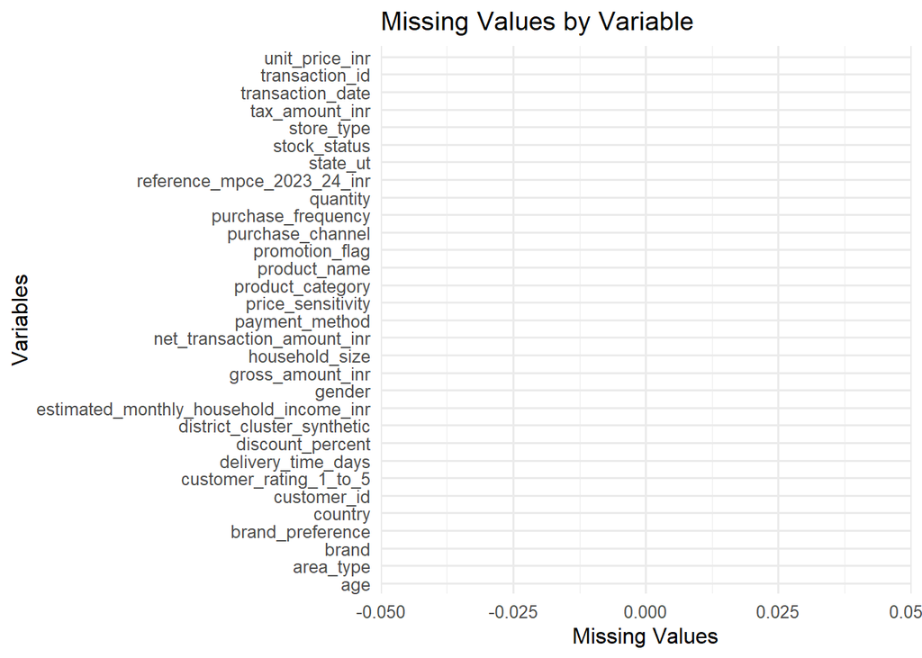

```r
ggplot(
  missing_report,
  aes(
    x = reorder(Variable, Missing_Count),
    y = Missing_Count
  )
) +
  geom_col(fill = "steelblue") +
  coord_flip() +
  labs(
    title = "Missing Values by Variable",
    x = "Variables",
    y = "Missing Values"
  )
```

# 5. Outlier Analysis

```r
numeric_data <- data %>%
  select(where(is.numeric))

outlier_report <- numeric_data %>%
  pivot_longer(
    everything(),
    names_to = "Variable",
    values_to = "Value"
  ) %>%
  group_by(Variable) %>%
  summarise(
    Q1 = quantile(Value, 0.25, na.rm = TRUE),
    Q3 = quantile(Value, 0.75, na.rm = TRUE),
    IQR_Value = IQR(Value, na.rm = TRUE),
    Lower_Limit = Q1 - 1.5 * IQR_Value,
    Upper_Limit = Q3 + 1.5 * IQR_Value,
    Outliers = sum(
      Value < Lower_Limit | Value > Upper_Limit,
      na.rm = TRUE
    ),
    .groups = "drop"
  )

knitr::kable(outlier_report)
```

| Variable | Q1 | Q3 | IQR_Value | Lower_Limit | Upper_Limit | Outliers |
| --- | --- | --- | --- | --- | --- | --- |
| age | 29.0000 | 47.00 | 18.0000 | 2.00000 | 74.0000 | 512 |
| customer_rating_1_to_5 | 3.0000 | 4.00 | 1.0000 | 1.50000 | 5.5000 | 780 |
| delivery_time_days | 0.0000 | 0.00 | 0.0000 | 0.00000 | 0.0000 | 41513 |
| discount_percent | 5.3000 | 16.00 | 10.7000 | -10.75000 | 32.0500 | 5245 |
| estimated_monthly_household_income_inr | 36190.0000 | 100370.00 | 64180.0000 | -60080.00000 | 196640.0000 | 9836 |
| gross_amount_inr | 85.1700 | 321.63 | 236.4600 | -269.52000 | 676.3200 | 9811 |
| household_size | 3.0000 | 6.00 | 3.0000 | -1.50000 | 10.5000 | 0 |
| net_transaction_amount_inr | 80.3600 | 316.46 | 236.1000 | -273.79000 | 670.6100 | 9437 |
| quantity | 2.0000 | 4.00 | 2.0000 | -1.00000 | 7.0000 | 1100 |
| reference_mpce_2023_24_inr | 3670.0000 | 6574.00 | 2904.0000 | -686.00000 | 10930.0000 | 445 |
| tax_amount_inr | 4.4600 | 28.94 | 24.4800 | -32.26000 | 65.6600 | 13562 |
| unit_price_inr | 33.9875 | 112.71 | 78.7225 | -84.09625 | 230.7937 | 3080 |

# 6. Descriptive Statistics

```r
descriptive_stats <- numeric_data %>%
  summarise(
    across(
      everything(),
      list(
        Mean = ~mean(.x, na.rm = TRUE),
        Median = ~median(.x, na.rm = TRUE),
        SD = ~sd(.x, na.rm = TRUE),
        Minimum = ~min(.x, na.rm = TRUE),
        Maximum = ~max(.x, na.rm = TRUE)
      )
    )
  )

knitr::kable(
  t(descriptive_stats),
  digits = 2
)
```

| age_Mean | 38.36 |
| --- | --- |
| age_Median | 38.00 |
| age_SD | 12.32 |
| age_Minimum | 18.00 |
| age_Maximum | 80.00 |
| household_size_Mean | 4.34 |
| household_size_Median | 4.00 |
| household_size_SD | 2.09 |
| household_size_Minimum | 1.00 |
| household_size_Maximum | 10.00 |
| estimated_monthly_household_income_inr_Mean | 76954.20 |
| estimated_monthly_household_income_inr_Median | 61260.00 |
| estimated_monthly_household_income_inr_SD | 57681.65 |
| estimated_monthly_household_income_inr_Minimum | 5000.00 |
| estimated_monthly_household_income_inr_Maximum | 300000.00 |
| reference_mpce_2023_24_inr_Mean | 5362.88 |
| reference_mpce_2023_24_inr_Median | 5377.00 |
| reference_mpce_2023_24_inr_SD | 1688.18 |
| reference_mpce_2023_24_inr_Minimum | 2739.00 |
| reference_mpce_2023_24_inr_Maximum | 13927.00 |
| quantity_Mean | 3.04 |
| quantity_Median | 3.00 |
| quantity_SD | 1.44 |
| quantity_Minimum | 1.00 |
| quantity_Maximum | 12.00 |
| unit_price_inr_Mean | 77.76 |
| unit_price_inr_Median | 60.60 |
| unit_price_inr_SD | 55.27 |
| unit_price_inr_Minimum | 1.68 |
| unit_price_inr_Maximum | 360.10 |
| discount_percent_Mean | 11.52 |
| discount_percent_Median | 9.70 |
| discount_percent_SD | 7.98 |
| discount_percent_Minimum | 0.00 |
| discount_percent_Maximum | 35.00 |
| gross_amount_inr_Mean | 236.21 |
| gross_amount_inr_Median | 166.92 |
| gross_amount_inr_SD | 216.94 |
| gross_amount_inr_Minimum | 1.75 |
| gross_amount_inr_Maximum | 2738.01 |
| tax_amount_inr_Mean | 21.32 |
| tax_amount_inr_Median | 11.18 |
| tax_amount_inr_SD | 25.21 |
| tax_amount_inr_Minimum | 0.25 |
| tax_amount_inr_Maximum | 384.35 |
| net_transaction_amount_inr_Mean | 230.39 |
| net_transaction_amount_inr_Median | 161.32 |
| net_transaction_amount_inr_SD | 212.60 |
| net_transaction_amount_inr_Minimum | 1.66 |
| net_transaction_amount_inr_Maximum | 2670.79 |
| delivery_time_days_Mean | 0.48 |
| delivery_time_days_Median | 0.00 |
| delivery_time_days_SD | 1.05 |
| delivery_time_days_Minimum | 0.00 |
| delivery_time_days_Maximum | 4.00 |
| customer_rating_1_to_5_Mean | 3.76 |
| customer_rating_1_to_5_Median | 4.00 |
| customer_rating_1_to_5_SD | 0.86 |
| customer_rating_1_to_5_Minimum | 1.00 |
| customer_rating_1_to_5_Maximum | 5.00 |

# 7. Rural vs Urban Analysis

## 7.1 Transaction Count

```r
area_summary <- data %>%
  filter(!is.na(area_type)) %>%
  count(area_type)

knitr::kable(area_summary)
```

| area_type | n |
| --- | --- |
| Rural | 115972 |
| Urban | 84028 |

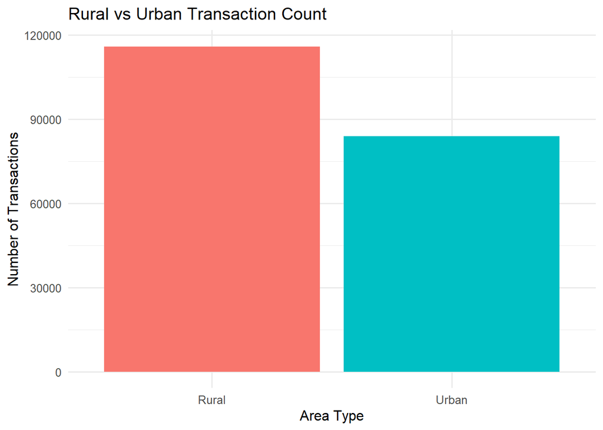

```r
ggplot(
  area_summary,
  aes(x = area_type, y = n, fill = area_type)
) +
  geom_col() +
  labs(
    title = "Rural vs Urban Transaction Count",
    x = "Area Type",
    y = "Number of Transactions"
  ) +
  guides(fill = "none")
```

## 7.2 Spending Comparison

```r
area_spending <- data %>%
  filter(
    !is.na(area_type),
    !is.na(net_transaction_amount_inr)
  ) %>%
  group_by(area_type) %>%
  summarise(
    Transactions = n(),
    Average_Spending = mean(
      net_transaction_amount_inr
    ),
    Median_Spending = median(
      net_transaction_amount_inr
    ),
    Total_Spending = sum(
      net_transaction_amount_inr
    ),
    .groups = "drop"
  )

knitr::kable(area_spending, digits = 2)
```

| area_type | Transactions | Average_Spending | Median_Spending | Total_Spending |
| --- | --- | --- | --- | --- |
| Rural | 115972 | 243.62 | 171.11 | 28252581 |
| Urban | 84028 | 212.14 | 147.80 | 17825685 |

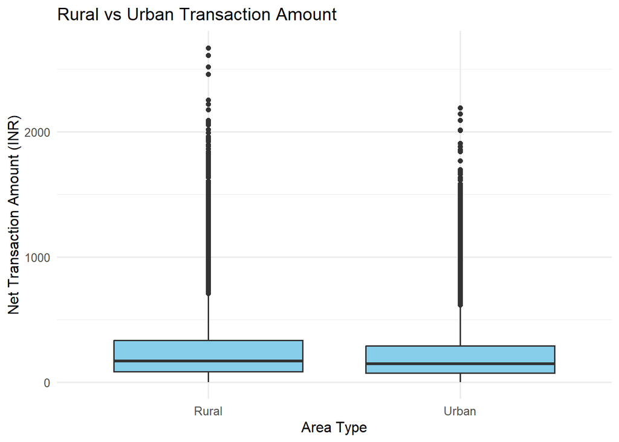

```r
ggplot(
  data,
  aes(
    x = area_type,
    y = net_transaction_amount_inr
  )
) +
  geom_boxplot(fill = "skyblue", na.rm = TRUE) +
  labs(
    title = "Rural vs Urban Transaction Amount",
    x = "Area Type",
    y = "Net Transaction Amount (INR)"
  )
```

## 7.3 Hypothesis Testing

```r
# H0: Rural and urban mean transaction amounts are equal.
# H1: Rural and urban mean transaction amounts differ.

test_data <- data %>%
  filter(
    area_type %in% c("Rural", "Urban"),
    !is.na(net_transaction_amount_inr)
  )

if(
  all(c("Rural", "Urban") %in% unique(test_data$area_type)) &&
  all(table(test_data$area_type) >= 2)
) {
  t.test(
    net_transaction_amount_inr ~ area_type,
    data = test_data
  )
}
```

```
##
##  Welch Two Sample t-test
##
## data:  net_transaction_amount_inr by area_type
## t = 33.442, df = 192651, p-value < 2.2e-16
## alternative hypothesis: true difference in means between group Rural and group Urban is not equal to 0
## 95 percent confidence interval:
##  29.63096 33.32048
## sample estimates:
## mean in group Rural mean in group Urban
##            243.6155            212.1398
```

# 8. Product Category Analysis

```r
category_summary <- data %>%
  filter(!is.na(product_category)) %>%
  count(product_category, sort = TRUE)

knitr::kable(category_summary)
```

| product_category | n |
| --- | --- |
| Packaged Foods | 43595 |
| Staples & Edible Oils | 31280 |
| Personal Care | 27816 |
| Dairy & Bakery | 27205 |
| Home Care | 25747 |
| Beverages | 22381 |
| Health & Hygiene | 12424 |
| Baby Care | 9552 |

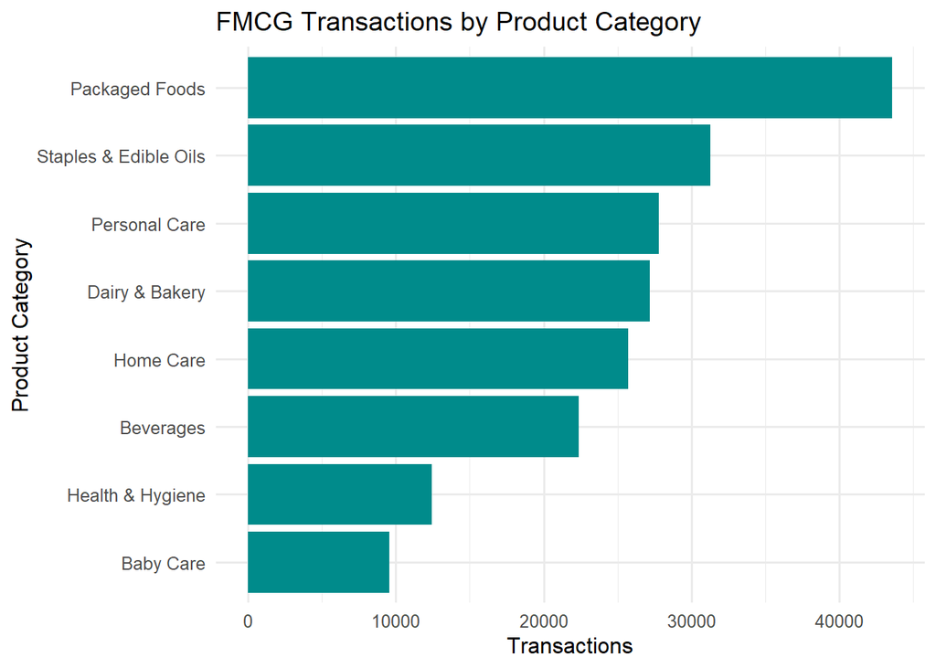

```r
ggplot(
  category_summary,
  aes(
    x = reorder(product_category, n),
    y = n
  )
) +
  geom_col(fill = "darkcyan") +
  coord_flip() +
  labs(
    title = "FMCG Transactions by Product Category",
    x = "Product Category",
    y = "Transactions"
  )
```

# 9. Brand Analysis

```r
brand_summary <- data %>%
  filter(!is.na(brand)) %>%
  count(brand, sort = TRUE) %>%
  slice_head(n = 15)

knitr::kable(brand_summary)
```

| brand | n |
| --- | --- |
| Regional/Local Brand | 41530 |
| HUL | 21784 |
| ITC | 16984 |
| Nestlé | 13721 |
| Dabur | 13585 |
| Britannia | 13575 |
| Amul | 11781 |
| Parle | 11686 |
| P&G | 11618 |
| Godrej Consumer | 10089 |
| Marico | 10045 |
| Tata Consumer | 8433 |
| Colgate-Palmolive | 8332 |
| Reckitt | 6837 |

[figure not shown]

```r
ggplot(
  brand_summary,
  aes(
    x = reorder(brand, n),
    y = n
  )
) +
  geom_col(fill = "coral") +
  coord_flip() +
  labs(
    title = "Top 15 FMCG Brands",
    x = "Brand",
    y = "Transaction Count"
  )
```

# 10. Rural vs Urban Product Preferences

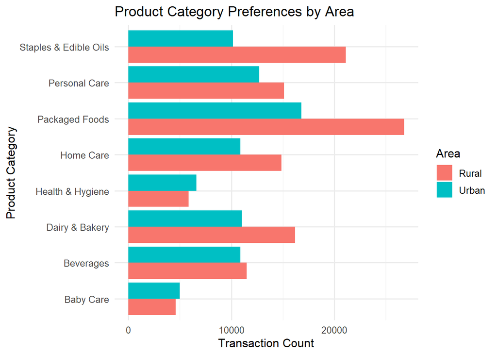

```r
category_area <- data %>%
  filter(
    !is.na(product_category),
    !is.na(area_type)
  ) %>%
  count(product_category, area_type)

ggplot(
  category_area,
  aes(
    x = product_category,
    y = n,
    fill = area_type
  )
) +
  geom_col(position = "dodge") +
  coord_flip() +
  labs(
    title = "Product Category Preferences by Area",
    x = "Product Category",
    y = "Transaction Count",
    fill = "Area"
  )
```

# 11. State-wise Analysis

```r
state_summary <- data %>%
  filter(!is.na(state_ut)) %>%
  count(state_ut, sort = TRUE)

knitr::kable(state_summary)
```

| state_ut | n |
| --- | --- |
| Uttar Pradesh | 30425 |
| Maharashtra | 18587 |
| Bihar | 16279 |
| Madhya Pradesh | 11878 |
| West Bengal | 11862 |
| Karnataka | 11053 |
| Tamil Nadu | 10880 |
| Rajasthan | 10769 |
| Gujarat | 9806 |
| Odisha | 6678 |
| Assam | 5553 |
| Andhra Pradesh | 5533 |
| Telangana | 5462 |
| Kerala | 5449 |
| Delhi | 5435 |
| Jharkhand | 5392 |
| Haryana | 4435 |
| Chhattisgarh | 4422 |
| Punjab | 4271 |
| Jammu & Kashmir | 3304 |
| Uttarakhand | 2153 |
| Himachal Pradesh | 1740 |
| Tripura | 1049 |
| Meghalaya | 914 |
| Goa | 870 |
| Manipur | 856 |
| Mizoram | 664 |
| Chandigarh | 646 |
| Puducherry | 629 |
| Arunachal Pradesh | 628 |
| Nagaland | 623 |
| Dadra & Nagar Haveli and Daman & Diu | 463 |
| Andaman & Nicobar Islands | 430 |
| Sikkim | 423 |
| Ladakh | 227 |
| Lakshadweep | 212 |

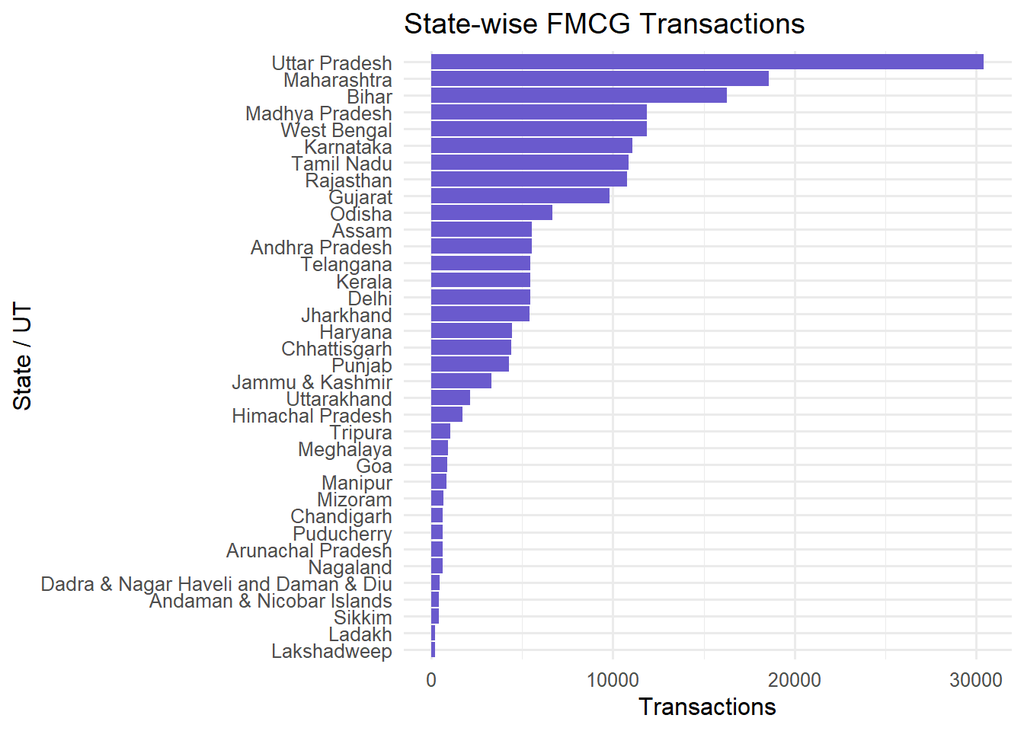

```r
ggplot(
  state_summary,
  aes(
    x = reorder(state_ut, n),
    y = n
  )
) +
  geom_col(fill = "slateblue") +
  coord_flip() +
  labs(
    title = "State-wise FMCG Transactions",
    x = "State / UT",
    y = "Transactions"
  )
```

# 12. Payment Method Analysis

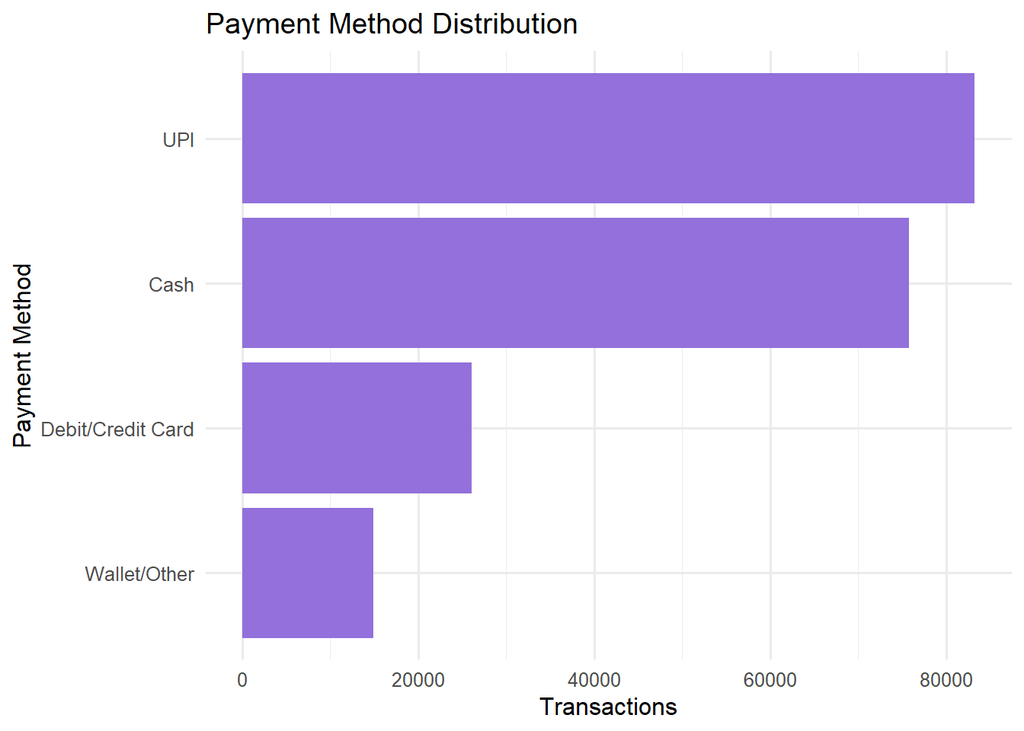

```r
payment_summary <- data %>%
  filter(!is.na(payment_method)) %>%
  count(payment_method, sort = TRUE)

ggplot(
  payment_summary,
  aes(
    x = reorder(payment_method, n),
    y = n
  )
) +
  geom_col(fill = "mediumpurple") +
  coord_flip() +
  labs(
    title = "Payment Method Distribution",
    x = "Payment Method",
    y = "Transactions"
  )
```

# 13. Purchase Frequency Analysis

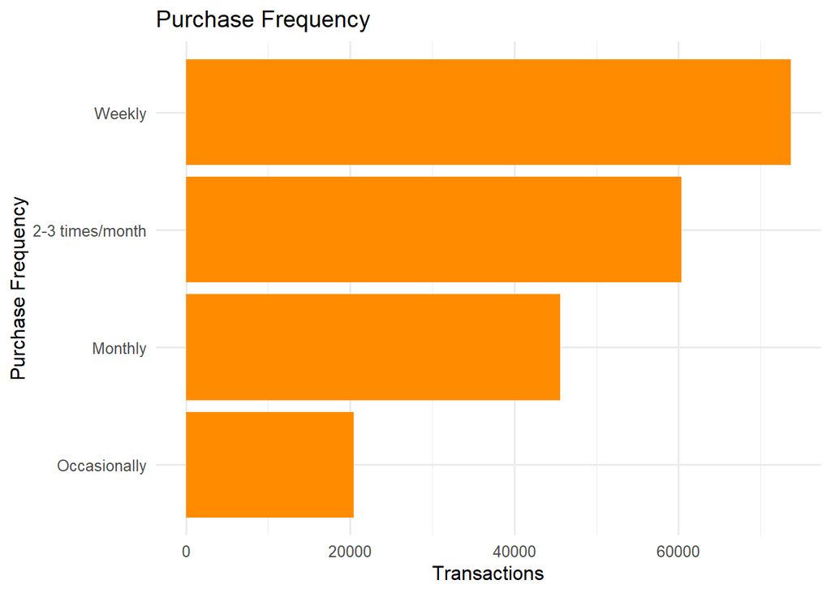

```r
frequency_summary <- data %>%
  filter(!is.na(purchase_frequency)) %>%
  count(purchase_frequency, sort = TRUE)

ggplot(
  frequency_summary,
  aes(
    x = reorder(purchase_frequency, n),
    y = n
  )
) +
  geom_col(fill = "darkorange") +
  coord_flip() +
  labs(
    title = "Purchase Frequency",
    x = "Purchase Frequency",
    y = "Transactions"
  )
```

# 14. Income and Reference MPCE Analysis

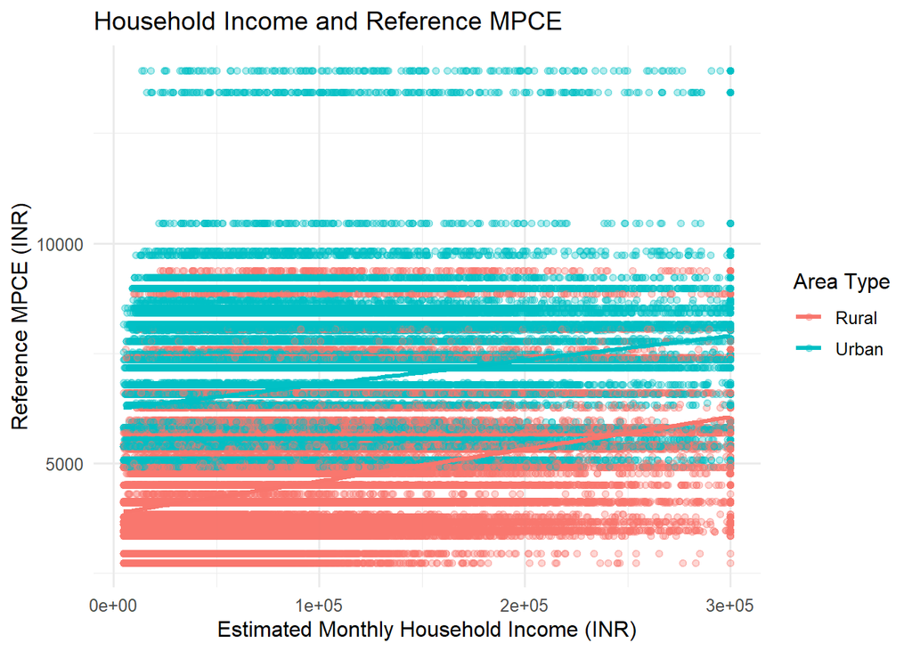

```r
ggplot(
  data,
  aes(
    x = estimated_monthly_household_income_inr,
    y = reference_mpce_2023_24_inr,
    color = area_type
  )
) +
  geom_point(alpha = 0.3) +
  geom_smooth(method = "lm", se = FALSE) +
  labs(
    title = "Household Income and Reference MPCE",
    x = "Estimated Monthly Household Income (INR)",
    y = "Reference MPCE (INR)",
    color = "Area Type"
  )
```

# 15. Correlation Analysis

[figure not shown]

```r
correlation_data <- data %>%
  select(
    age,
    household_size,
    estimated_monthly_household_income_inr,
    reference_mpce_2023_24_inr,
    quantity,
    unit_price_inr,
    discount_percent,
    gross_amount_inr,
    tax_amount_inr,
    net_transaction_amount_inr,
    delivery_time_days,
    customer_rating_1_to_5
  )

correlation_matrix <- cor(
  correlation_data,
  use = "pairwise.complete.obs"
)

corrplot(
  correlation_matrix,
  method = "color",
  type = "upper",
  tl.col = "black",
  tl.srt = 45,
  addCoef.col = "black",
  number.cex = 0.55
)
```

# 16. Regression Analysis

The outcome is net transaction amount. We use customer and purchasing characteristics as predictors. We exclude gross amount, tax, discount, quantity and unit price because these are directly involved in calculating transaction value and could make the model misleading.

```r
model_data <- data %>%
  select(
    net_transaction_amount_inr,
    area_type,
    age,
    gender,
    household_size,
    estimated_monthly_household_income_inr,
    reference_mpce_2023_24_inr,
    product_category,
    brand_preference,
    purchase_frequency,
    purchase_channel,
    store_type,
    payment_method,
    promotion_flag,
    price_sensitivity,
    delivery_time_days,
    customer_rating_1_to_5
  ) %>%
  drop_na()

# Remove unused factor levels
model_data <- droplevels(model_data)

# Keep only predictors with variation
predictors <- setdiff(names(model_data),
                      "net_transaction_amount_inr")

predictors <- predictors[
  sapply(
    model_data[predictors],
    function(x) n_distinct(x) > 1
  )
]

# Random training/testing split
set.seed(123)

train_index <- sample(
  seq_len(nrow(model_data)),
  size = floor(0.8 * nrow(model_data))
)

train_data <- model_data[train_index, ]
test_data <- model_data[-train_index, ]

# Remove factor levels absent from training data
for(v in predictors) {
  if(is.factor(train_data[[v]])) {
    train_data[[v]] <- droplevels(train_data[[v]])

    test_data[[v]] <- factor(
      as.character(test_data[[v]]),
      levels = levels(train_data[[v]])
    )
  }
}

test_data <- test_data[complete.cases(test_data), ]

# Fit multiple linear regression
regression_formula <- reformulate(
  predictors,
  response = "net_transaction_amount_inr"
)

model <- lm(
  regression_formula,
  data = train_data
)

summary(model)
```

```
##
## Call:
## lm(formula = regression_formula, data = train_data)
##
## Residuals:
##     Min      1Q  Median      3Q     Max
## -344.00 -131.66  -63.50   72.72 2472.18
##
## Coefficients: (3 not defined because of singularities)
##                                            Estimate Std. Error t value Pr(>|t|)
## (Intercept)                               2.638e+02  5.408e+00  48.783  < 2e-16
## area_typeUrban                           -3.082e+01  1.533e+00 -20.110  < 2e-16
## age                                       7.488e-03  4.161e-02   0.180   0.8572
## genderMale                               -6.634e-01  1.035e+00  -0.641   0.5215
## genderOther/Prefer not to say             4.609e+00  3.710e+00   1.242   0.2141
## household_size                            4.127e-01  4.195e-01   0.984   0.3252
## estimated_monthly_household_income_inr   -9.555e-06  1.935e-05  -0.494   0.6215
## reference_mpce_2023_24_inr                6.505e-05  4.909e-04   0.133   0.8946
## product_categoryBeverages                 1.586e+01  2.803e+00   5.657 1.54e-08
## product_categoryDairy & Bakery           -3.383e+01  2.733e+00 -12.381  < 2e-16
## product_categoryHealth & Hygiene         -2.951e+00  3.122e+00  -0.945   0.3444
## product_categoryHome Care                 1.048e+02  2.752e+00  38.096  < 2e-16
## product_categoryPackaged Foods           -6.493e+01  2.597e+00 -25.002  < 2e-16
## product_categoryPersonal Care            -1.345e+01  2.722e+00  -4.942 7.74e-07
## product_categoryStaples & Edible Oils     2.384e+01  2.691e+00   8.861  < 2e-16
## brand_preferencePreferred brand          -1.167e+00  1.042e+00  -1.120   0.2628
## purchase_frequencyMonthly                -1.152e-01  1.423e+00  -0.081   0.9355
## purchase_frequencyOccasionally            1.577e+00  1.857e+00   0.849   0.3956
## purchase_frequencyWeekly                  2.284e-03  1.257e+00   0.002   0.9986
## purchase_channelKirana/General Store     -9.501e-01  2.282e+00  -0.416   0.6771
## purchase_channelSupermarket/Modern Trade -2.502e+00  2.442e+00  -1.025   0.3055
## purchase_channelWholesale/Other          -2.971e+00  2.344e+00  -1.268   0.2049
## store_typeOnline                                 NA         NA      NA       NA
## store_typeSupermarket                            NA         NA      NA       NA
## store_typeWholesale/Other                        NA         NA      NA       NA
## payment_methodDebit/Credit Card          -5.685e-01  1.697e+00  -0.335   0.7377
## payment_methodUPI                        -1.233e+00  1.174e+00  -1.050   0.2939
## payment_methodWallet/Other               -1.789e+00  2.060e+00  -0.869   0.3850
## promotion_flagPromotion/Discount Applied -3.460e+01  1.027e+00 -33.697  < 2e-16
## price_sensitivityLow                     -1.197e+00  2.265e+00  -0.529   0.5971
```

[output cut: 28 more lines]

```
## store_typeWholesale/Other
## payment_methodDebit/Credit Card
## payment_methodUPI
## payment_methodWallet/Other
## promotion_flagPromotion/Discount Applied ***
## price_sensitivityLow
## price_sensitivityMedium                  .
## delivery_time_days
## customer_rating_1_to_5
## ---
## Signif. codes:  0 '***' 0.001 '**' 0.01 '*' 0.05 '.' 0.1 ' ' 1
##
## Residual standard error: 204.9 on 159970 degrees of freedom
## Multiple R-squared:  0.07057,    Adjusted R-squared:  0.0704
## F-statistic: 418.9 on 29 and 159970 DF,  p-value: < 2.2e-16
```

```r
# Coefficients
broom::tidy(model)
```

```
## # A tibble: 33 × 5
##    term                                    estimate std.error statistic  p.value
##    <chr>                                      <dbl>     <dbl>     <dbl>    <dbl>
##  1 (Intercept)                              2.64e+2 5.41         48.8   0
##  2 area_typeUrban                          -3.08e+1 1.53        -20.1   7.84e-90
##  3 age                                      7.49e-3 0.0416        0.180 8.57e- 1
##  4 genderMale                              -6.63e-1 1.04         -0.641 5.22e- 1
##  5 genderOther/Prefer not to say            4.61e+0 3.71          1.24  2.14e- 1
##  6 household_size                           4.13e-1 0.419         0.984 3.25e- 1
##  7 estimated_monthly_household_income_inr  -9.56e-6 0.0000194    -0.494 6.21e- 1
##  8 reference_mpce_2023_24_inr               6.51e-5 0.000491      0.133 8.95e- 1
##  9 product_categoryBeverages                1.59e+1 2.80          5.66  1.54e- 8
## 10 product_categoryDairy & Bakery          -3.38e+1 2.73        -12.4   3.44e-35
## # ℹ 23 more rows
```

```r
# Model performance on test data
predictions <- predict(model, newdata = test_data)

actual <- test_data$net_transaction_amount_inr

if(length(actual) > 0) {

  RMSE <- sqrt(mean((actual - predictions)^2))

  MAE <- mean(abs(actual - predictions))

  R_squared <- 1 -
    sum((actual - predictions)^2) /
    sum((actual - mean(actual))^2)

  data.frame(
    RMSE = RMSE,
    MAE = MAE,
    Test_R_Squared = R_squared
  )
}
```

```
##       RMSE      MAE Test_R_Squared
## 1 205.5214 148.8074     0.06723383
```

# 17. Regression Diagnostics

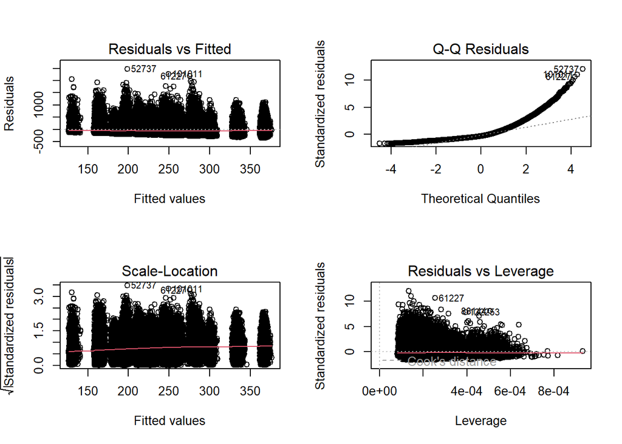

```r
par(mfrow = c(2, 2))

plot(model)
```

```r
par(mfrow = c(1, 1))

# Heteroscedasticity test
lmtest::bptest(model)
```

```
##
##  studentized Breusch-Pagan test
##
## data:  model
## BP = 2576.7, df = 29, p-value < 2.2e-16
```

```r
# Multicollinearity
try(car::vif(model), silent = TRUE)
```

# 18. Actual vs Predicted Graph

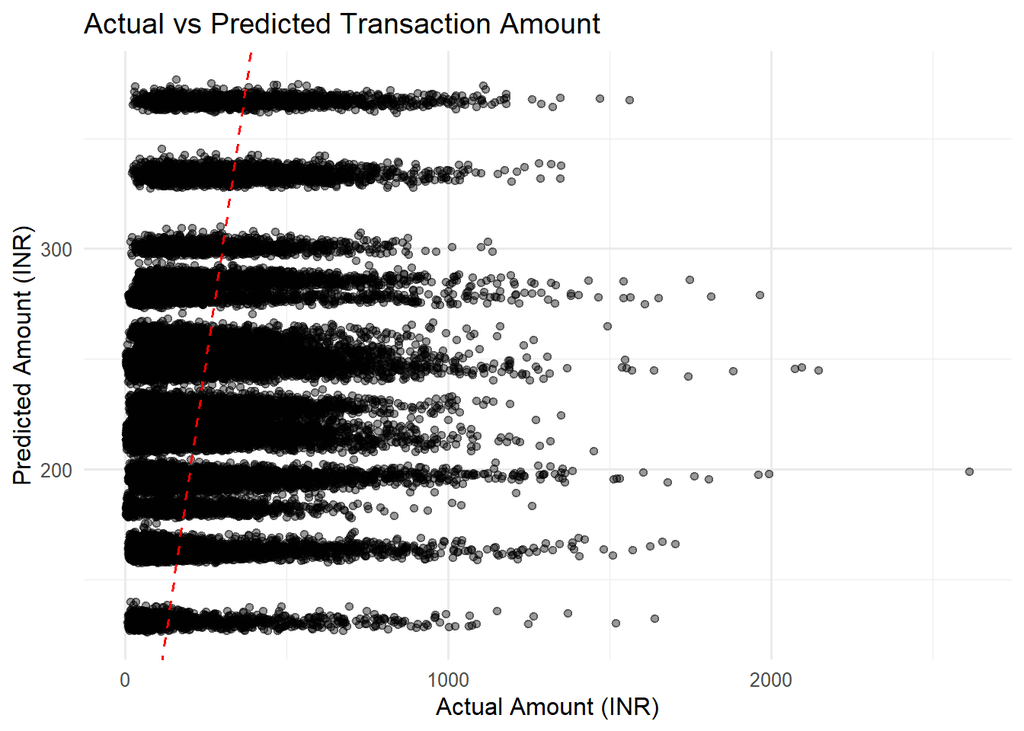

```r
prediction_results <- data.frame(
  Actual = actual,
  Predicted = as.numeric(predictions)
)

ggplot(
  prediction_results,
  aes(x = Actual, y = Predicted)
) +
  geom_point(alpha = 0.4) +
  geom_abline(
    slope = 1,
    intercept = 0,
    color = "red",
    linetype = "dashed"
  ) +
  labs(
    title = "Actual vs Predicted Transaction Amount",
    x = "Actual Amount (INR)",
    y = "Predicted Amount (INR)"
  )
```

# 19. Export Results

```r
write.csv(
  data,
  "cleaned_fmcg_dataset.csv",
  row.names = FALSE
)

write.csv(
  missing_report,
  "missing_values_report.csv",
  row.names = FALSE
)

write.csv(
  outlier_report,
  "outlier_analysis.csv",
  row.names = FALSE
)

write.csv(
  area_spending,
  "rural_urban_comparison.csv",
  row.names = FALSE
)

write.csv(
  category_summary,
  "category_analysis.csv",
  row.names = FALSE
)

write.csv(
  brand_summary,
  "brand_analysis.csv",
  row.names = FALSE
)
```

## #project report:

#Research Objective 1: FMCG Consumption by Rural and Urban Households

To examine whether the difference in average transaction spending is statistically significant, a Welch Two Sample t-test was conducted.

Overall, the results indicate that rural areas have higher transaction representation, higher average transaction spending and higher total transaction value in the analysed dataset. The statistical test also confirms a significant difference in average transaction spending between rural and urban groups.

From a business perspective, these findings suggest that rural markets deserve considerable attention when planning FMCG distribution, product availability and marketing strategies.

#Research Objective 2: Penetration and Distribution of Different FMCG Categories

Rural areas also demonstrate higher transaction counts in Personal Care, Dairy & Bakery, Home Care and Beverages. However, urban areas record higher transactions in Health & Hygiene and Baby Care.

Overall, Packaged Foods emerges as the leading FMCG category across both market segments. Rural areas demonstrate stronger transaction representation across most categories, whereas Health & Hygiene and Baby Care show higher urban representation.

From a business perspective, FMCG companies can consider strengthening packaged food and essential product distribution across rural markets while investigating the relatively higher urban representation of Health & Hygiene and Baby Care. Category-specific inventory and marketing strategies may help address the differences observed between the two market segments.

#Analysis of FMCG Consumption Trends Over Time:

```r
# ==========================================
# RESEARCH OBJECTIVE 6
# FMCG CONSUMPTION TRENDS OVER TIME
# ==========================================

library(dplyr)
library(ggplot2)
library(lubridate)
library(scales)

# 1. Convert transaction date
data$transaction_date <- as.Date(data$transaction_date)

# 2. Monthly consumption analysis
monthly_trend <- data %>%
  filter(
    !is.na(transaction_date),
    !is.na(area_type)
  ) %>%
  mutate(
    Month = floor_date(transaction_date, "month")
  ) %>%
  group_by(Month, area_type) %>%
  summarise(
    Total_Transactions = n(),
    Total_Spending = sum(
      net_transaction_amount_inr,
      na.rm = TRUE
    ),
    Average_Spending = mean(
      net_transaction_amount_inr,
      na.rm = TRUE
    ),
    .groups = "drop"
  ) %>%
  arrange(Month)

# 3. Display monthly results
print(monthly_trend, n = Inf)
```

```
## # A tibble: 730 × 5
##     Month      area_type Total_Transactions Total_Spending Average_Spending
##     <date>     <fct>                  <int>          <dbl>            <dbl>
##   1 0001-01-01 Rural                    288         69676.             242.
##   2 0001-01-01 Urban                    239         48083.             201.
##   3 0001-02-01 Rural                    288         74334.             258.
##   4 0001-02-01 Urban                    199         43287.             218.
##   5 0001-03-01 Rural                    346         77357.             224.
##   6 0001-03-01 Urban                    207         42369.             205.
##   7 0001-04-01 Rural                    302         69383.             230.
##   8 0001-04-01 Urban                    242         50412.             208.
##   9 0001-05-01 Rural                    335         79315.             237.
##  10 0001-05-01 Urban                    225         46969.             209.
##  11 0001-06-01 Rural                    311         73539.             236.
##  12 0001-06-01 Urban                    220         47291.             215.
```

[output cut: 718 more lines]

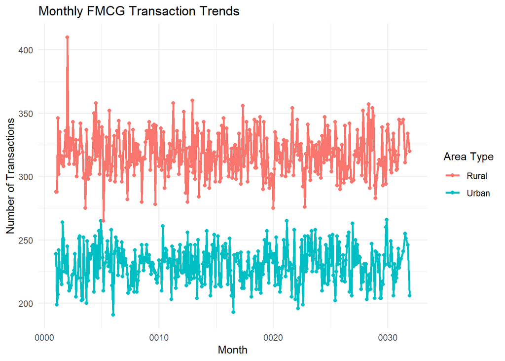

```r
# 4. Monthly transaction volume trend
ggplot(monthly_trend,
       aes(x = Month,
           y = Total_Transactions,
           color = area_type,
           group = area_type)) +
  geom_line(linewidth = 1) +
  geom_point() +
  labs(
    title = "Monthly FMCG Transaction Trends",
    x = "Month",
    y = "Number of Transactions",
    color = "Area Type"
  ) +
  theme_minimal()
```

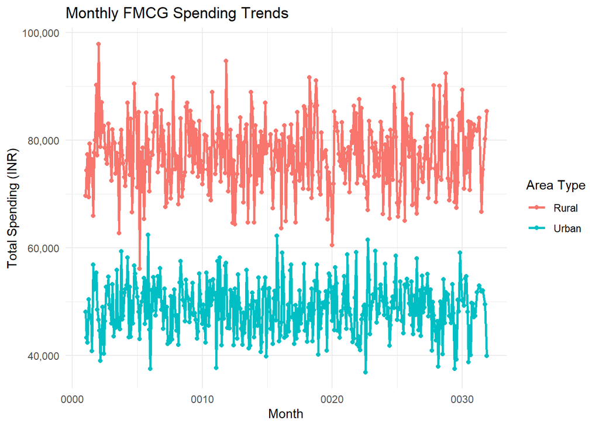

```r
# 5. Monthly total spending trend
ggplot(monthly_trend,
       aes(x = Month,
           y = Total_Spending,
           color = area_type,
           group = area_type)) +
  geom_line(linewidth = 1) +
  geom_point() +
  scale_y_continuous(labels = comma) +
  labs(
    title = "Monthly FMCG Spending Trends",
    x = "Month",
    y = "Total Spending (INR)",
    color = "Area Type"
  ) +
  theme_minimal()
```

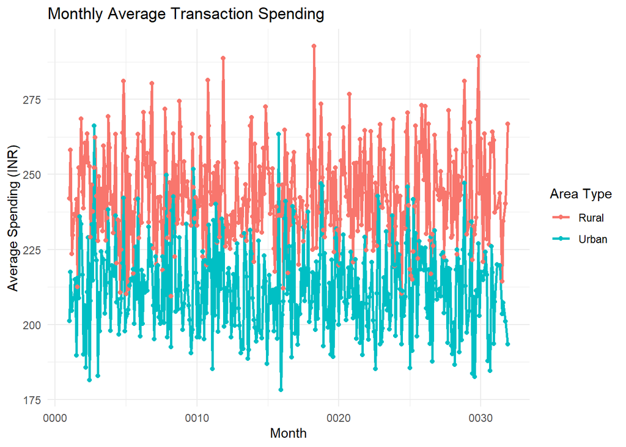

```r
# 6. Monthly average spending trend
ggplot(monthly_trend,
       aes(x = Month,
           y = Average_Spending,
           color = area_type,
           group = area_type)) +
  geom_line(linewidth = 1) +
  geom_point() +
  labs(
    title = "Monthly Average Transaction Spending",
    x = "Month",
    y = "Average Spending (INR)",
    color = "Area Type"
  ) +
  theme_minimal()
```

```r
# 7. Overall monthly trend
overall_monthly_trend <- data %>%
  filter(!is.na(transaction_date)) %>%
  mutate(
    Month = floor_date(transaction_date, "month")
  ) %>%
  group_by(Month) %>%
  summarise(
    Total_Transactions = n(),
    Total_Spending = sum(
      net_transaction_amount_inr,
      na.rm = TRUE
    ),
    Average_Spending = mean(
      net_transaction_amount_inr,
      na.rm = TRUE
    ),
    .groups = "drop"
  ) %>%
  arrange(Month)

print(overall_monthly_trend, n = Inf)
```

```
## # A tibble: 365 × 4
##     Month      Total_Transactions Total_Spending Average_Spending
##     <date>                  <int>          <dbl>            <dbl>
##   1 0001-01-01                527        117759.             223.
##   2 0001-02-01                487        117621.             242.
##   3 0001-03-01                553        119726.             217.
##   4 0001-04-01                544        119795.             220.
##   5 0001-05-01                560        126284.             226.
##   6 0001-06-01                531        120830.             228.
##   7 0001-07-01                531        117183.             221.
##   8 0001-08-01                574        122777.             214.
##   9 0001-09-01                558        129909.             233.
##  10 0001-10-01                545        133099.             244.
##  11 0001-11-01                573        145532.             254.
##  12 0001-12-01                540        125696.             233.
```

[output cut: 353 more lines]

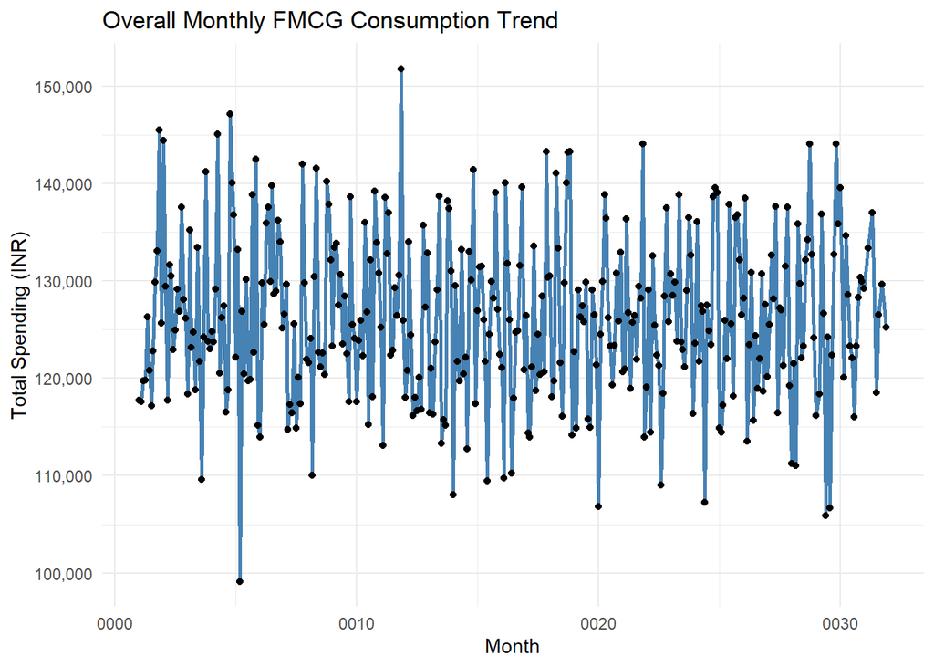

```r
# 8. Overall monthly spending graph
ggplot(overall_monthly_trend,
       aes(x = Month, y = Total_Spending)) +
  geom_line(linewidth = 1, color = "steelblue") +
  geom_point() +
  scale_y_continuous(labels = comma) +
  labs(
    title = "Overall Monthly FMCG Consumption Trend",
    x = "Month",
    y = "Total Spending (INR)"
  ) +
  theme_minimal()
```

1. Monthly FMCG Consumption Analysis

Monthly transaction records were analysed to examine changes in FMCG consumption expenditure over time. The analysis considered total transactions, total spending, and average transaction spending across rural and urban areas.

2. Graphical Analysis

Figure: Overall Monthly FMCG Consumption Trend

The graphical representation illustrates the variation in total monthly FMCG spending throughout the observed dataset.

3. Interpretation and Key Findings
4. Fluctuating Consumption: Monthly FMCG spending shows considerable fluctuations throughout the observed period.
5. No Consistent Growth: The spending pattern does not indicate a continuous upward trend.
6. No Consistent Decline: Similarly, the graph does not show a continuous downward trend.
7. Variation in Expenditure: Most monthly spending observations appear to fall between approximately ₹1,10,000 and ₹1,40,000, with occasional higher and lower values.
8. Rural and Urban Differences: The monthly comparison shows differences in spending between rural and urban transactions, with rural spending generally higher in the initial months displayed in the analysis.
9. Overall Finding

The analysis indicates that FMCG consumption expenditure in the generated dataset fluctuates over the observed period rather than following a consistent increasing or decreasing trend. These monthly variations reflect changes in transaction volume and spending patterns across rural and urban areas.

#CONCLUSION:

The project, titled “Indian FMCG Market Analysis: Rural vs Urban Business Analytics,” was undertaken to examine differences in FMCG consumption patterns, category distribution, regional variations, consumer spending behaviour, household characteristics, and consumption trends over time.

Among the different FMCG categories, Packaged Foods recorded the highest number of transactions, followed by Staples & Edible Oils and Personal Care. Rural areas recorded higher transaction counts in six out of eight product categories, while urban areas recorded higher counts in Baby Care and Health & Hygiene.

Regional analysis showed variations in transaction distribution across states. Uttar Pradesh recorded the highest number of transactions among the states visible in the initial analysis, followed by Maharashtra and Bihar, indicating differences in regional representation within the dataset.

The consumer spending analysis showed that the average net transaction amount was ₹230.39, while the median was ₹161.32. This difference suggests that higher-value transactions influence the overall average spending.

The consumption trend analysis indicated fluctuations in monthly FMCG expenditure rather than a consistent increasing or decreasing pattern across the observed dataset.

Overall, the project demonstrates how data analytics techniques can be used to identify consumption patterns, compare rural and urban markets, understand product category preferences, and examine differences in consumer spending and household characteristics. These findings can help FMCG businesses understand transaction patterns and support decisions related to product distribution, marketing strategies, and regional market planning.

Although the analysis provides useful insights, the dataset is synthetic and the transaction dates have limitations in calendar-year representation. Therefore, the findings represent patterns within the constructed dataset and should not be considered actual nationwide FMCG consumption estimates.

In conclusion, the project successfully demonstrates the application of data cleaning, exploratory data analysis, statistical testing, data visualisation, correlation analysis, and regression techniques to an FMCG business analytics problem. It highlights the importance of data-driven decision-making in understanding rural and urban consumer markets.